Tài liệu này mang giấy phép Creative Commons Attribution (CC BY SA). Bản gốc copyright (c) Barba group

[@barbagroup](https://github.com/barbagroup/CFDPython)

*Thực hành CFD với Python!*

# Bài 4. Phương trình Laplace hai chiều

Phương trình Laplace hai chiều là phương trình đạo hàm riêng cấp hai dạng eliptic: $$\frac{\partial^2 u}{\partial x^2} + \frac{\partial^2 u}{\partial y^2} = 0$$ Sử dụng toán tử Laplace phương trình được viết lại ở dạng $\Delta u = 0$. Như các bạn thấy trong phương trình này không có đạo hàm riêng theo thời gian, điều này có nghĩa là nghiệm u không phụ thuộc (không thay đổi) theo thời gian: $\partial/\partial t = 0$. Một trong các hiện tượng vật lý mà phương trình mô tả đó là quá trình dẫn nhiệt ổn định, không có nguồn nhiệt. Trường hợp có nguồn nhiệt được mô tả bằng phương trình Poisson: $\Delta u = f(x,y)$. Khi giải phương trình Laplace có ba dạng điều kiện biên:

*Điều kiện biên Diriclet:* cho giá trị nhiệt độ trên biên

*Điều kiện biên Neumann:* cho giá trị đạo hàm hàm nhiệt trên biên, chính là tốc độ phân tán nhiệt ra môi trường xung quanh

*Điều kiện biên hỗn hợp:* kết hợp hai điều kiện trên

**Bài toán:**

- Điều kiện ban đầu: u(x, y) = 0 trên miền hình vuông (0,1)x(0,1)
- Điều kiện biên hỗn hợp: u(0, y) = 0; u(1, y) = y; $\partial u/\partial y = 0$ tại y = 0, y = 1

**Sơ đồ sai phân:** Để giải phương trình Laplace, ta sử dụng sơ đồ `5 điểm`: $$\frac{u_{i+1, j} - 2 u_{i, j} + u_{i-1, j}}{(\Delta x)^2} + \frac{u_{i, j+1} - 2 u_{i, j} + u_{i, j-1}}{(\Delta y)^2} = 0$$ với sai số xấp xỉ $O((\Delta x)^2, (\Delta y)^2)$.

Do không có thời gian nên phương pháp giải phương trình Laplace không giống như những gì ta làm ở các bài trước. Có nhiều phương pháp khác nhau được áp dụng. Ở đây ta sử dụng `phương pháp lặp` như sau:

- đưa phương trình về dạng: $$u_{ij} = \frac{(\Delta y)^2 (u_{i+1, j} + u_{i-1, j}) + (\Delta x)^2 (u_{i, j+1} + u_{i, j-1})}{2((\Delta x)^2 + (\Delta y)^2)} $$
- thay điều kiện ban đầu, điều kiện biên vào phương trình trên tìm $u_{i, j}$ ở bước lặp thứ nhất.
- sử dụng kết quả tìm được làm dữ liệu đầu vào để tìm $u_{i, j}$ ở bước tiếp theo
- lặp lại bước trên cho tới khi nghiệm tìm được ở hai bước liên tiếp sai khác rất nhỏ, khi đó ta nói nghiệm hội tụ. Nếu ta lặp quá trình này N bước, thì với N càng lớn nghiệm càng chính xác. Hoặc ta có thể kiểm tra điều kiện sau (còn được gọi là `chuẩn`) để dừng quá trình lặp:

$$\frac {\sum (|u_{i, j}^{sau}| - |u_{i,j}^{trước}|)}{\sum |u_{ij}^{trước}|} < \varepsilon$$

**Coding:**

- Với bài toán hai chiều (x, y) ta coi như đang làm việc với một chiều x tại các giá trị y cố định
- Để chứa giá trị u ta khai báo mảng hai chiều gồm ny hàng, nx cột. u[j, i] - phần tử hàng j (trục y), cột i (trục x)
- Để biểu diễn giá trị u(x, y) ta sẽ sử dụng thư viện `mplot3d`, xây dựng hàm plot(u)
- Để tìm nghiệm ta xây dựng hàm solver(u, y, epsilon)

```python
import numpy as np
import matplotlib.pyplot as plt
from matplotlib import cm #colormap
from mpl_toolkits.mplot3d import Axes3D #khai báo thư viện để vẽ đồ thị 3D

#chia lưới
nx = 21
ny = 21
dx = 1./(nx-1)
dy = 1./(ny-1)

x = np.linspace(0, 1, nx)
y = np.linspace(0, 1, ny)

#điều kiện ban đầu
u = np.zeros((ny, nx)) # tạo mảng ny hàng, nx cột, giá trị mỗi phần tử u[j, i] = 0

#điều kiện biên
u[:, 0] = 0 #u = 0, x = 0
u[:, -1] = y #u = y, x = 1
u[0, :] = u[1, :] #du/dy = 0, y = 0
u[-1, :] = u[-2, :] #du/dy = 0, y = 1
```

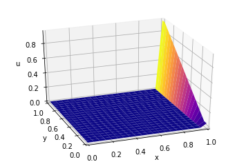

```python
#khai báo hàm plot với dữ liệu đầu vào là giá trị hàm u
def plot(u):
    fig = plt.figure() #Top level container for all plot elements.
    ax = fig.gca(projection='3d') #Get the current Axes
    X, Y = np.meshgrid(x, y) # tạo lưới điểm (X, Y)
    surf = ax.plot_surface(X, Y, u, cmap=cm.plasma)
    ax.set_xlim(0, 1)
    ax.set_ylim(0, 1)
    ax.set_xlabel('x')
    ax.set_ylabel('y')
    ax.set_zlabel('u')
    ax.view_init(30, 250)
    #fig.colorbar(surf)
    plt.show()

#biểu diễn điều kiện ban đầu, điều kiện biên
plot(u)
```

```python
#hàm solver với các dữ liệu đầu vào cần thiết: u, y, epsilon

def solver(u, y, epsilon):
    un = u.copy()           #khai báo mảng un chứa giá trị tạm thời
    norm = 2*epsilon        #gán giá trị chuẩn ban đầu > epsilon
    while (norm > epsilon): #nếu norm <= epsilon thì thoát khỏi vòng lặp
        un = u.copy()       #lưu giá trị hiện tại

        #tính u[j, i] ở bước tiếp theo
        u[1:-1, 1:-1] = (dy**2*(un[1:-1, 2:] + un[1:-1, 0:-2]) + dx**2*(un[2:, 1:-1] + un[0:-2, 1:-1]))/\
                        (2*(dx**2 + dy**2))
        #điều kiện biên
        u[:, 0] = 0         #u = 0, x = 0
        u[:, -1] = y        #u = 1, x = 1
        u[0, :] = u[1, :]   #du/dy = 0, y = 0
        u[-1, :] = u[-2, :] #du/dy = 0, y = 1

        #tính chuẩn
        norm = np.sum(np.abs(u[:]) - np.abs(un[:]))/np.sum(np.abs(un[:]))

    return u
```

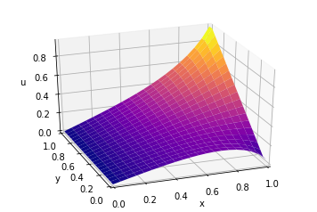

```python
#gọi hàm solver với dữ liệu đầu vào đã được thiết lập ở trên
u = solver(u, y, 1e-5) #epsilon = 10^-5

#vẽ đồ thị hàm u
plot(u)
```

Những gì các bạn thu được từ bài 4 sẽ được áp dụng để giải hệ phương trình Navier-Stokes cho chất lỏng không nén được ở cuối khóa học.

## Bài 5. Phương trình Burgers (dòng chảy không nhớt)